# DATA 607 Assignment 2

Mohamed Hassan-El Serafi

2023-02-05

## Loading Necessary Libraries

```r
library(tidyverse)
library(RMySQL)
library(dbplyr)
library(DBI)
library(keyring)
```

## Converting SQL table to R DataFrame

I imported a table called Movie Ratings Survey through the MySQL database Movie Rating. In order to hide the password, I used the Keyring library in order to gain access into the MySQL Database. The dataset consists of ratings from family and friends of movies that were recently released. The rating scale is from 1 to 5, 1 representing the person extremely dislikes the movie and would not recommend the movie, and 5 being extremely likes the movie and would recommend the movie.

```r
#psswd <- .rs.askForPassword("Database Password:")
sql_db_con <- dbConnect(MySQL(), user='root', password=key_get('MySQL', 'root'),
                        dbname="Movie_Rating", host='localhost')


dbListTables(sql_db_con)
```

```
## [1] "movie ratings survey" "movie_ratings"        "movie_ratings_survey"
```

```r
movie_ratings <- tbl(sql_db_con, 'Movie_Ratings_Survey')
movie_ratings
```

```
## # Source:   table<Movie_Ratings_Survey> [?? x 3]
## # Database: mysql 8.0.32 [@localhost:/Movie_Rating]
##    Name  Film              Rating
##    <chr> <chr>              <int>
##  1 Tim   Women Talking          3
##  2 Tim   Top Gun: Maverick      5
##  3 Tim   Avatar                 4
##  4 Tim   Elvis                  5
##  5 Tim   Wakanda Forever        4
##  6 Tim   Smile                  0
##  7 Cindy Women Talking          4
##  8 Cindy Top Gun: Maverick      3
##  9 Cindy Avatar                 5
## 10 Cindy Elvis                  2
## # … with more rows
```

```r
dbListFields(sql_db_con, 'Movie_Ratings_Survey')
```

```
## [1] "Name"   "Film"   "Rating"
```

```r
rs = dbSendQuery(sql_db_con, "select * from Movie_Ratings_Survey")
data <- fetch(rs, n=-1)
data
```

```
##       Name              Film Rating
## 1      Tim     Women Talking      3
## 2      Tim Top Gun: Maverick      5
## 3      Tim            Avatar      4
## 4      Tim             Elvis      5
## 5      Tim   Wakanda Forever      4
## 6      Tim             Smile      0
## 7    Cindy     Women Talking      4
## 8    Cindy Top Gun: Maverick      3
## 9    Cindy            Avatar      5
## 10   Cindy             Elvis      2
## 11   Cindy   Wakanda Forever      0
## 12   Cindy             Smile      5
## 13 Carolyn     Women Talking      4
## 14 Carolyn Top Gun: Maverick      0
```

[output cut: 22 more lines]

## Snapshot of Data

Now that my data is loaded, I explored the dataset further:

```r
glimpse(data)
```

```
## Rows: 36
## Columns: 3
## $ Name   <chr> "Tim", "Tim", "Tim", "Tim", "Tim", "Tim", "Cindy", "Cindy", "Ci…
## $ Film   <chr> "Women Talking", "Top Gun: Maverick", "Avatar", "Elvis", "Wakan…
## $ Rating <int> 3, 5, 4, 5, 4, 0, 4, 3, 5, 2, 0, 5, 4, 0, 5, 5, 5, 4, 5, 0, 5, …
```

```r
dim(data)
```

```
## [1] 36  3
```

```r
mean(data$Rating)
```

```
## [1] 3.638889
```

```r
median(data$Rating)
```

```
## [1] 4
```

```r
colSums(data==0)
```

```
##   Name   Film Rating
##      0      0      5
```

## Finding Average and Median Ratings by Name and Film

There are 5 values in the dataset that have a 0 rating, which indicates that the respondents may not have watched the movie and therefore did not give a rating for the movie. To fill in those values, I subsetted the data looking at the mean and median based on Name and Film, respectively. From the results, I will choose how to fill in the zero values.

### Average Rating by Name

```r
new_data <- data %>%
  group_by(Name) %>%
  summarise(new_rating = mean(Rating))
new_data
```

```
## # A tibble: 6 × 2
##   Name    new_rating
##   <chr>        <dbl>
## 1 Alex          3.67
## 2 Carolyn       3.83
## 3 Cindy         3.17
## 4 Tiffany       3.83
## 5 Tim           3.5
## 6 Wesley        3.83
```

### Average Rating by Film

```r
new_film_data <- data %>%
  group_by(Film) %>%
  summarise(new_rating = mean(Rating))
new_film_data
```

```
## # A tibble: 6 × 2
##   Film              new_rating
##   <chr>                  <dbl>
## 1 Avatar                  4.67
## 2 Elvis                   3.83
## 3 Smile                   3.67
## 4 Top Gun: Maverick       2.83
## 5 Wakanda Forever         3.67
## 6 Women Talking           3.17
```

### Median Rating by Name

```r
new_data_median <- data %>%
  group_by(Name) %>%
  summarise(new_rating = median(Rating))
new_data_median
```

```
## # A tibble: 6 × 2
##   Name    new_rating
##   <chr>        <dbl>
## 1 Alex           4.5
## 2 Carolyn        4.5
## 3 Cindy          3.5
## 4 Tiffany        4.5
## 5 Tim            4
## 6 Wesley         4
```

### Median Rating by Film

```r
new_film_median <- data %>%
  group_by(Film) %>%
  summarise(new_rating = median(Rating))
new_film_median
```

```
## # A tibble: 6 × 2
##   Film              new_rating
##   <chr>                  <dbl>
## 1 Avatar                   5
## 2 Elvis                    4
## 3 Smile                    4.5
## 4 Top Gun: Maverick        3.5
## 5 Wakanda Forever          4
## 6 Women Talking            3.5
```

## Replacing Zero Values with NA

I transformed the zero values into NA values in order to replace the values with either the mean or median based on Name or Film.

```r
data[data == 0] <- NA
data
```

```
##       Name              Film Rating
## 1      Tim     Women Talking      3
## 2      Tim Top Gun: Maverick      5
## 3      Tim            Avatar      4
## 4      Tim             Elvis      5
## 5      Tim   Wakanda Forever      4
## 6      Tim             Smile     NA
## 7    Cindy     Women Talking      4
## 8    Cindy Top Gun: Maverick      3
## 9    Cindy            Avatar      5
## 10   Cindy             Elvis      2
## 11   Cindy   Wakanda Forever     NA
## 12   Cindy             Smile      5
## 13 Carolyn     Women Talking      4
## 14 Carolyn Top Gun: Maverick     NA
```

[output cut: 22 more lines]

## Handling Missing Data

For the values that have a zero, I will use the median value of the respondents’ response to the other movies they gave ratings for.

```r
final_dataset <- data %>%
        group_by(Name) %>%
        mutate_at("Rating", function(x) replace(x, is.na(x), median(x, na.rm = TRUE)))
final_dataset
```

```
## # A tibble: 36 × 3
## # Groups:   Name [6]
##    Name  Film              Rating
##    <chr> <chr>              <dbl>
##  1 Tim   Women Talking          3
##  2 Tim   Top Gun: Maverick      5
##  3 Tim   Avatar                 4
##  4 Tim   Elvis                  5
##  5 Tim   Wakanda Forever        4
##  6 Tim   Smile                  4
##  7 Cindy Women Talking          4
##  8 Cindy Top Gun: Maverick      3
##  9 Cindy Avatar                 5
## 10 Cindy Elvis                  2
## # … with 26 more rows
```

Checking to see if there’s any NA values in final_dataset created:

```r
sum(is.na(final_dataset))
```

```
## [1] 0
```

## Summarizing Final Dataset

```r
new_final_dataset <- final_dataset %>%
  group_by(Film) %>%
  summarise(new_final_rating = mean(Rating))
new_final_dataset
```

```
## # A tibble: 6 × 2
##   Film              new_final_rating
##   <chr>                        <dbl>
## 1 Avatar                        4.67
## 2 Elvis                         3.83
## 3 Smile                         4.33
## 4 Top Gun: Maverick             4.5
## 5 Wakanda Forever               4.33
## 6 Women Talking                 4
```

## Plotting new_final_dataset

I created a barplot using the new_final_dataset:

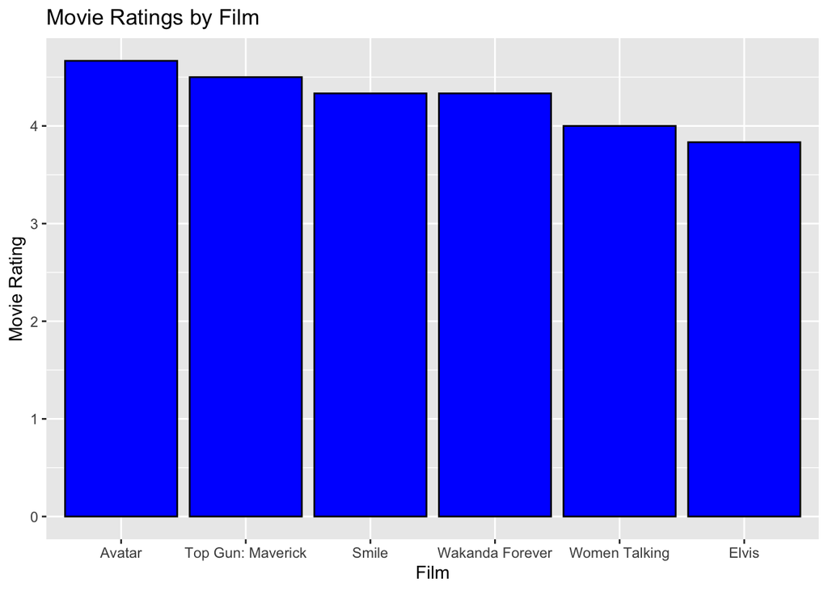

As the barplot shows, Avatar rated the highest among the respondents, while Elvis rated the lowest.